# Ron Meeting 06/24/21

Hannah Andrews

06/23/2021

Sample: There are 6157 complete cases on CAM variables at Wave 1.

# CAM Descriptives

## Frequencies and percentages on each variable

```
##              Item Category Frequency Percent Pcnt_of_nonMissing
## 1    aAcupuncture        0      6083    98.8               98.8
## 2    aAcupuncture        1        74     1.2                1.2
## 3    aBiofeedback        0      6109    99.2               99.2
## 4    aBiofeedback        1        48     0.8                0.8
## 5   aChiropractic        0      5418    88.0               88.0
## 6   aChiropractic        1       739    12.0               12.0
## 7     aEnergyHeal        0      6064    98.5               98.5
## 8     aEnergyHeal        1        93     1.5                1.5
## 9   aExerciseMove        0      5079    82.5               82.5
## 10  aExerciseMove        1      1078    17.5               17.5
## 11        aHerbal        0      5856    95.1               95.1
## 12        aHerbal        1       301     4.9                4.9
## 13      aVitamins        0      5875    95.4               95.4
## 14      aVitamins        1       282     4.6                4.6
```

[output cut: 16 more lines]

## Visualization of frequencies

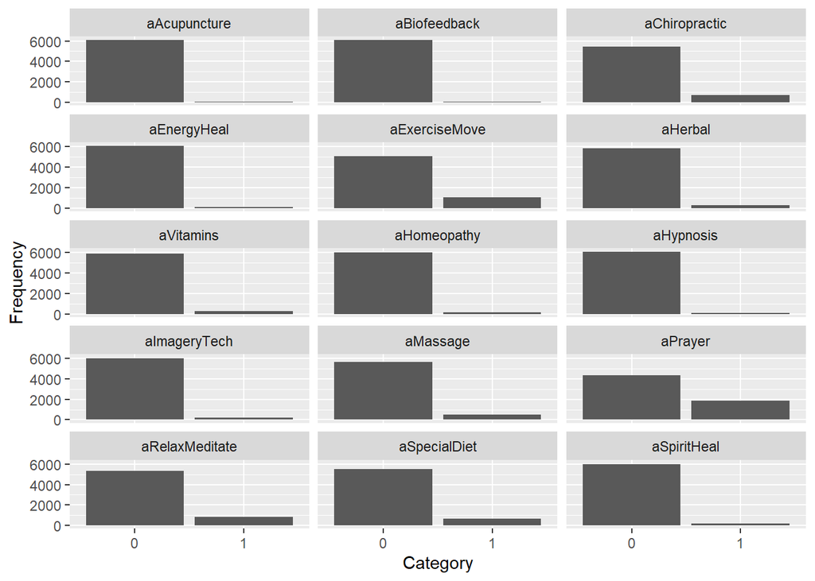

## Number of CAM treatments used in the past 12 months

```
## totalCams
##            0            1            2            3            4            5
## 0.4866006172 0.2320935521 0.1279844080 0.0729251259 0.0328081858 0.0190027611
##            6            7            8            9           10           11
## 0.0120188403 0.0063342537 0.0040604190 0.0021114179 0.0019490011 0.0014617509
##           13           15
## 0.0004872503 0.0001624168
```

```
##  Category    f   rf rf(%)   cf  cf(%)
##         0 2996 0.49 48.66 2996  48.66
##         1 1429 0.23 23.21 4425  71.87
##         2  788 0.13 12.80 5213  84.67
##         3  449 0.07  7.29 5662  91.96
##         4  202 0.03  3.28 5864  95.24
##         5  117 0.02  1.90 5981  97.14
##         6   74 0.01  1.20 6055  98.34
##         7   39 0.01  0.63 6094  98.98
##         8   25 0.00  0.41 6119  99.38
##         9   13 0.00  0.21 6132  99.59
##        10   12 0.00  0.19 6144  99.79
##        11    9 0.00  0.15 6153  99.94
##        13    3 0.00  0.05 6156  99.98
##        15    1 0.00  0.02 6157 100.00
```

# Analayses including all 15 CAMs

## Correlation matrix

Create and plot the tetrachoric correlation matrix for all CAMs.

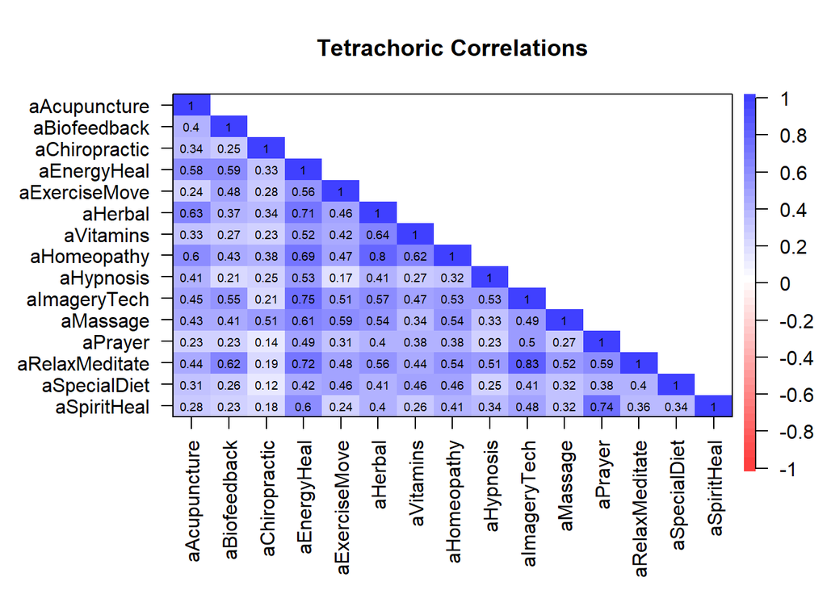

Check that items are not perfectly correlated with each other.

```
##                aA aB aC aEH aEM aHr aV aHm aHy aI aM aP aR aSD aSH
## aAcupuncture   1
## aBiofeedback   .  1
## aChiropractic  .     1
## aEnergyHeal    .  .  .  1
## aExerciseMove     .     .   1
## aHerbal        ,  .  .  ,   .   1
## aVitamins      .        .   .   ,   1
## aHomeopathy    .  .  .  ,   .   ,   ,  1
## aHypnosis      .        .       .      .   1
## aImageryTech   .  .     ,   .   .   .  .   .   1
## aMassage       .  .  .  ,   .   .   .  .   .   .  1
## aPrayer                 .   .   .   .  .       .     1
## aRelaxMeditate .  ,     ,   .   .   .  .   .   +  .  .  1
## aSpecialDiet   .        .   .   .   .  .       .  .  .  .  1
## aSpiritHeal             .       .      .   .   .  .  ,  .  .   1
## attr(,"legend")
## [1] 0 ' ' 0.3 '.' 0.6 ',' 0.8 '+' 0.9 '*' 0.95 'B' 1
```

## Test for correlation adequacy

I will test for correlation adequacy using Bartlett’s Sphericity test. This test tests the hypothesis that correlations between variables are greater than would be expected by chance. The null hypothesis states that all off diagonal are 0. If the null hypothesis is rejected there is correlation adequacy.

```
## $chisq
## [1] 66329.56
##
## $p.value
## [1] 0
##
## $df
## [1] 105
```

I reject the null hypothesis. The CAM items are adequately correlated.

## Test for sampling adequacy

I will test for sampling adequacy using the Kaiser-Meyer-Olkin (KMO) test.MSA refers to the overall measure of sampling adequacy. MSAi refer to the measure of sampling adequacy for each item. MSA is a measure of the proportion of variance among variables that might be common variance. The lower the proportion of variance that is common the more suited the data are for factor analysis.

MSA cutoffs: >.9 marvelous, .8s meritorious, .7s middling, .6s mediocre, .5s miserable, less than .5 is unacceptable.

```
## Kaiser-Meyer-Olkin factor adequacy
## Call: KMO(r = het.mat)
## Overall MSA =  0.76
## MSA for each item =
##   aAcupuncture   aBiofeedback  aChiropractic    aEnergyHeal  aExerciseMove
##           0.85           0.75           0.73           0.89           0.77
##        aHerbal      aVitamins    aHomeopathy      aHypnosis   aImageryTech
##           0.91           0.81           0.88           0.72           0.82
##       aMassage        aPrayer aRelaxMeditate   aSpecialDiet    aSpiritHeal
##           0.81           0.53           0.64           0.88           0.51
```

Items that may be a concern with regard to sampling adequacy: prayer or other spiritual practices, relaxation or meditation, and spiritual healing. Overall MSA indicates sampling adequacy.

## Determining the number of factors

First, I will run a parallel analysis. From RDocumentation: “``Parallel” analyis is a technique that compares the scree of factors of the observed data with that of a random data matrix of the same size as the original."

Parallel analysis completed using maximum likelihood factoring method.

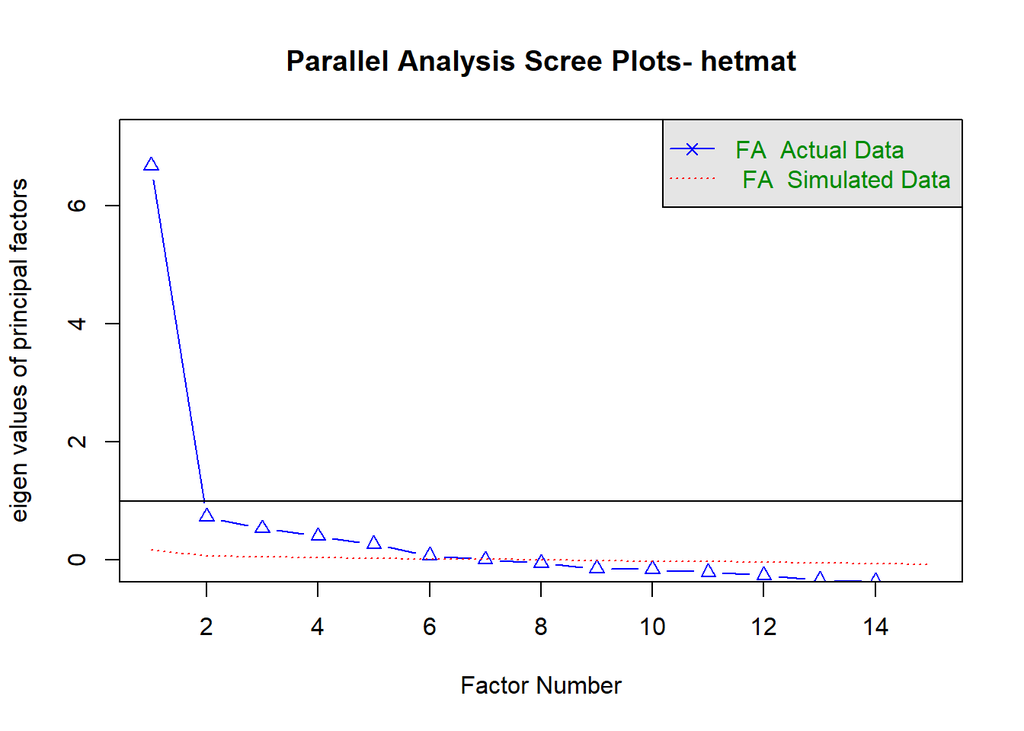

```
## Parallel analysis suggests that the number of factors =  6  and the number of components =  NA
```

I received many warning messages stating “A cell entry of 0 was replaced with correct = 0.5. Check your data!” This has to do with continuity when computing a tetrachoric correlation matrix. I added 1 to all values in the dataframe to check that the issue was not the 0/1 values. The results were the same.

From Statistics of DOOM notes: i. The dark line is set at one, which is part of the Kaiser criterion. This method is an older rule of thumb that is not well supported anymore. You would look at the number of eigenvalues that are greater than 1 (or .70 in new literature). This rule tends to overestimate the number of factors/components needed. ii. The red dotted line is the random data set used to test this analysis. Your data is randomly reordered to see how many factors are better than chance. iii. The blue line and triangles are your eigenvalues from the real dataset. iv. You want to look at where the blue and red lines cross.

Note: Scree plots are a visual depiction of the eigenvalues. Look for the large drop off to figure out how many factors to use.

## Kaiser Criterion

```r
# older kaiser criterion, number of eigenvalues greater than 1
sum(nofactors$fa.values > 1.0)
```

```
## [1] 1
```

```r
# new kaiser criterion, number of eigenvalues greater than 0.7
sum(nofactors$fa.values > .7)
```

```
## [1] 2
```

New kaiser criterion rule (eigenvalues greater than 0.7) suggests 2 factors.

After readings Ayers and Kronenfeld (2010), I will test the old CAM domains posted by the National Center for Complementary and Alternative Medicine (NCCAM), now the National Center for Complementary and Integrative Medicine (NCCIM). Then I will test the domains found by Ayers and Kronenfeld (2010). Finally, I will test the NCCIM’s current CAM domains before performing exploratory factor analysis on the MIDUS data.

# Compare model fit for 1, 2, 3, 4, 5, 6 factor models including all CAMs

Factor method: Maximum likelihood Rotation method: Oblique

```
##                  Model       TLI       BIC       RMSR     RMSEA
## 1 Factor Mode1 Model 1 0.5927004 22422.125 0.09183285 0.2042507
## 2 Factor Model Model 2 0.6147528 17875.291 0.07479222 0.1986336
## 3 Factor Model Model 3 0.7101065 11028.394 0.06324245 0.1722974
## 4 Factor Model Model 4 0.7615625  7272.309 0.05559871 0.1562511
## 5 Factor Model Model 5 0.8052751  4600.918 0.04192812 0.1411962
## 6 Factor Model Model 6 0.8210908  3151.229 0.02896826 0.1353333
##                RMSEA_lower_bound RMSEA_upper_bound RMSEA_confidence       CFI
## 1 Factor Mode1         0.2020598         0.2064837              0.9 0.6509240
## 2 Factor Model         0.1962480         0.2010624              0.9 0.7212149
## 3 Factor Model         0.1696741         0.1749637              0.9 0.8261205
## 4 Factor Model         0.1533336         0.1592143              0.9 0.8842378
## 5 Factor Model         0.1379007         0.1445433              0.9 0.9258594
## 6 Factor Model         0.1315285         0.1392000              0.9 0.9489164
```

# Models excluding prayer, spiritual healing, and energy healing

## Tetrachoric correlation matrix

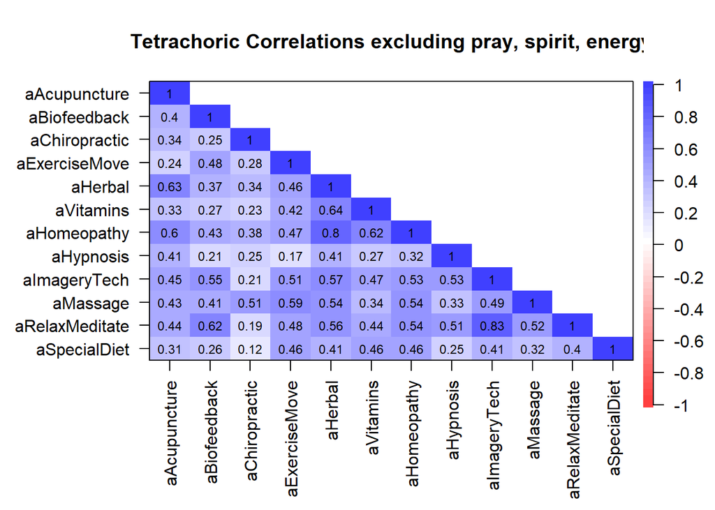

## Bartlett’s Test of Spherecity I will test for correlation adequacy using Bartlett’s Sphericity test. This test tests the hypothesis that correlations between variables are greater than would be expected by chance. The null hypothesis states that all off diagonal are 0. If the null hypothesis is rejected there is correlation adequacy.

```
## $chisq
## [1] 42574.65
##
## $p.value
## [1] 0
##
## $df
## [1] 66
```

## KMO Test for sampling adequacy

I will test for sampling adequacy using the Kaiser-Meyer-Olkin (KMO) test.MSA refers to the overall measure of sampling adequacy. MSAi refer to the measure of sampling adequacy for each item. MSA is a measure of the proportion of variance among variables that might be common variance. The lower the proportion of variance that is common the more suited the data are for factor analysis.

MSA cutoffs: >.9 marvelous, .8s meritorious, .7s middling, .6s mediocre, .5s miserable, less than .5 is unacceptable.

```
## Kaiser-Meyer-Olkin factor adequacy
## Call: KMO(r = het.mat12)
## Overall MSA =  0.86
## MSA for each item =
##   aAcupuncture   aBiofeedback  aChiropractic  aExerciseMove        aHerbal
##           0.87           0.85           0.80           0.83           0.87
##      aVitamins    aHomeopathy      aHypnosis   aImageryTech       aMassage
##           0.89           0.89           0.86           0.87           0.87
## aRelaxMeditate   aSpecialDiet
##           0.83           0.88
```

Great.

## Parallel Analysis

### Maximum Likelihood

First, I will run a parallel analysis. From RDocumentation: “``Parallel” analyis is a technique that compares the scree of factors of the observed data with that of a random data matrix of the same size as the original."

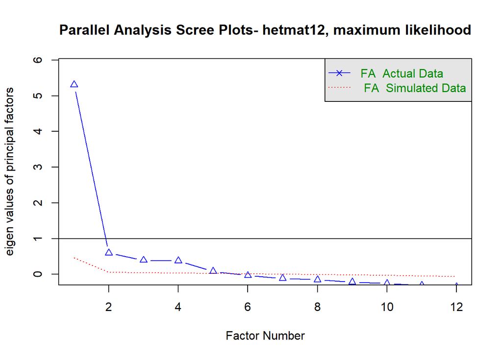

```
## Parallel analysis suggests that the number of factors =  5  and the number of components =  NA
```

### Principal axis

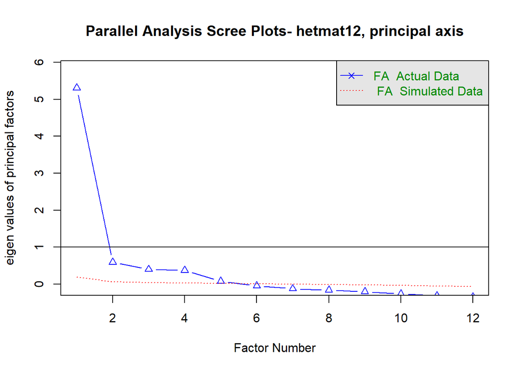

```
## Parallel analysis suggests that the number of factors =  5  and the number of components =  NA
```

### Minimum Residual

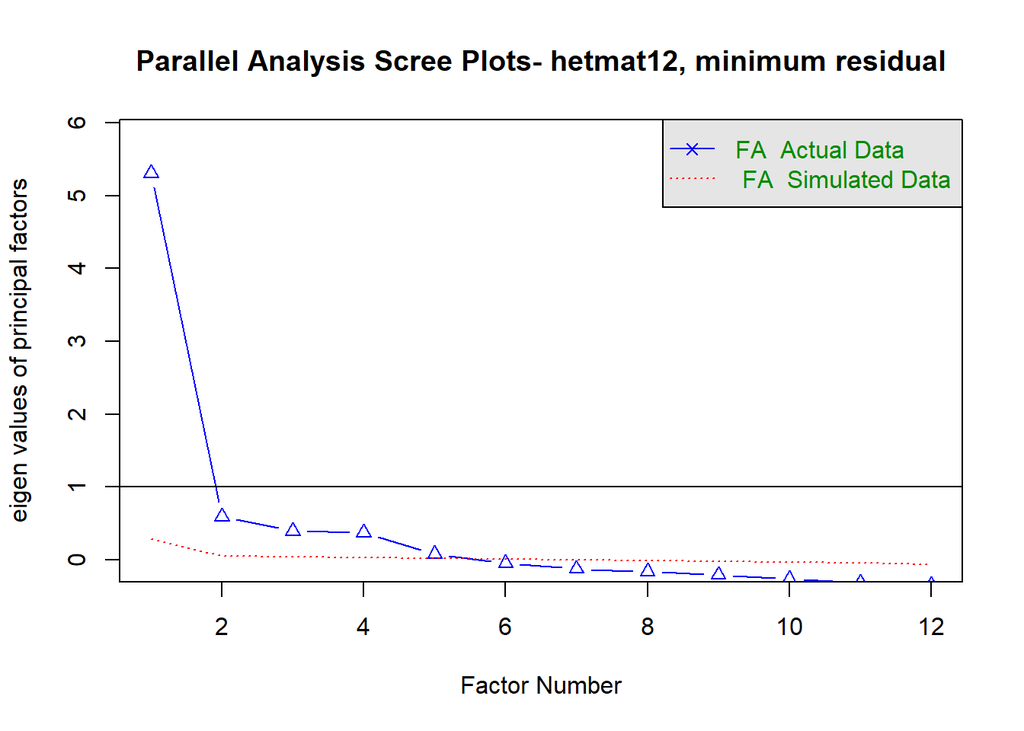

```
## Parallel analysis suggests that the number of factors =  5  and the number of components =  NA
```

From Statistics of DOOM notes: i. The dark line is set at one, which is part of the Kaiser criterion. This method is an older rule of thumb that is not well supported anymore. You would look at the number of eigenvalues that are greater than 1 (or .70 in new literature). This rule tends to overestimate the number of factors/components needed. ii. The red dotted line is the random data set used to test this analysis. Your data is randomly reordered to see how many factors are better than chance. iii. The blue line and triangles are your eigenvalues from the real dataset. iv. You want to look at where the blue and red lines cross.

Note: Scree plots are a visual depiction of the eigenvalues. Look for the large drop off to figure out how many factors to use.

## Kaiser Criterion

Old Kaiser Criterion

```r
# older kaiser criterion, number of eigenvalues greater than 1
sum(acams12_parallelMl$fa.values > 1.0)
```

```
## [1] 1
```

New Kaiser Criterion

```
## [1] 1
```

## Create table for model comparisons of all models excluding prayer, spiritual healing, and energy

Factor alphas input in order from factor loadings matrix. For example, if ML3 is the first column of factors presented in the factor loadings table when called, the alpha will be input under reliabilityF1. Reliability calculated using Kuder-Richardson Formula 20 (KR-20), a measure for testing the reliability of binary items. If an item loads equally on multiple factors, I include it in the reliability calculation for all factors it loads on. In notes, I refer to factors in order of reliability columns. For example, “Massage loads onto factors 1 and 2” refers to reliabilityF1 and reliabilityF2.  
(Code chunk here, does not appear in html output.)

## Maximum likelihood, Three factor

### Orthogonal rotation: Varimax

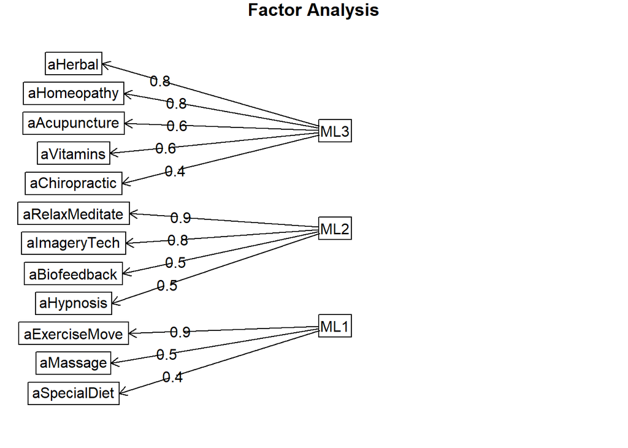

Massage and special diet load equally onto multiple factors. When calculating alphas, I include them for all factors they load onto.

### Oblique rotation: promax

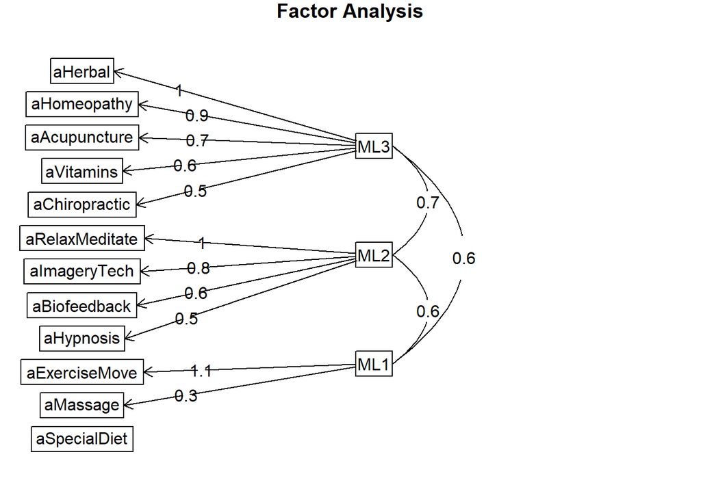

Special diet does not load on any factors. Massage loads equally on two factors.

### Oblique rotation: oblimin

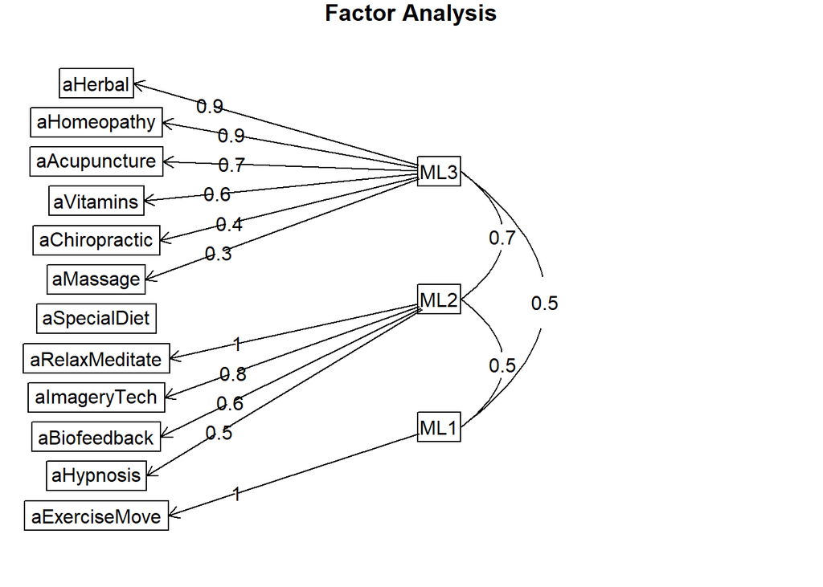

Massage loads fairly equally on factors 1 and 3. Special diet does not load on any factors.

### Oblique rotation: cluster

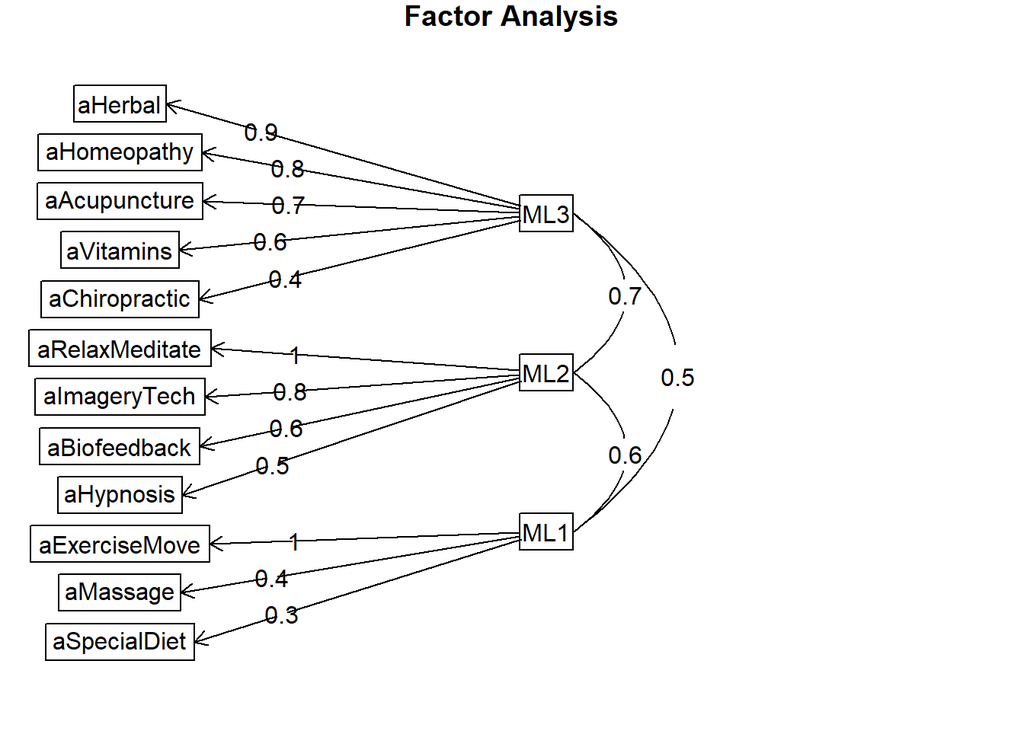

All items load on one factor. Special diet is questionable - less than .1 difference factor loading between factors 1 and 3. About .12 difference in loadings on factors 1 and 3 for massage.

## Principal Axis, Three factor

### Orthogonal rotation: varimax

```
## Warning in fa.stats(r = r, f = f, phi = phi, n.obs = n.obs, np.obs = np.obs, :
## The estimated weights for the factor scores are probably incorrect. Try a
## different factor score estimation method.
```

```
## Warning in fac(r = r, nfactors = nfactors, n.obs = n.obs, rotate = rotate, : An
## ultra-Heywood case was detected. Examine the results carefully
```

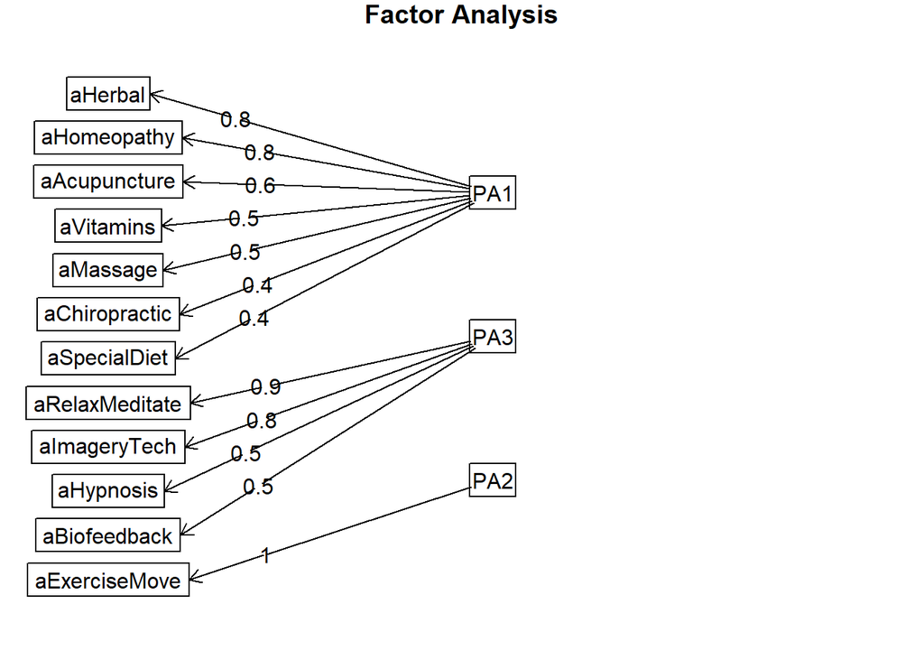

## Minimum Residual, Three Factors

Minimum residual solutions produce error message warning about ultra-Heywood case. Not included in model comparisons table or in the results here.

## Maximum Likelihood, Four Factor

### Orthogonal rotation: Varimax

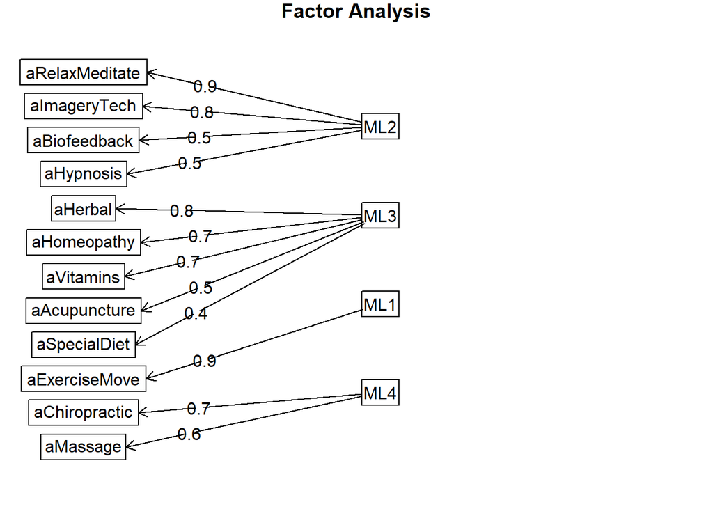

Acupuncture loads on 1, 2, 4. Special diet loads on 2, 3.

### Oblique rotation: promax

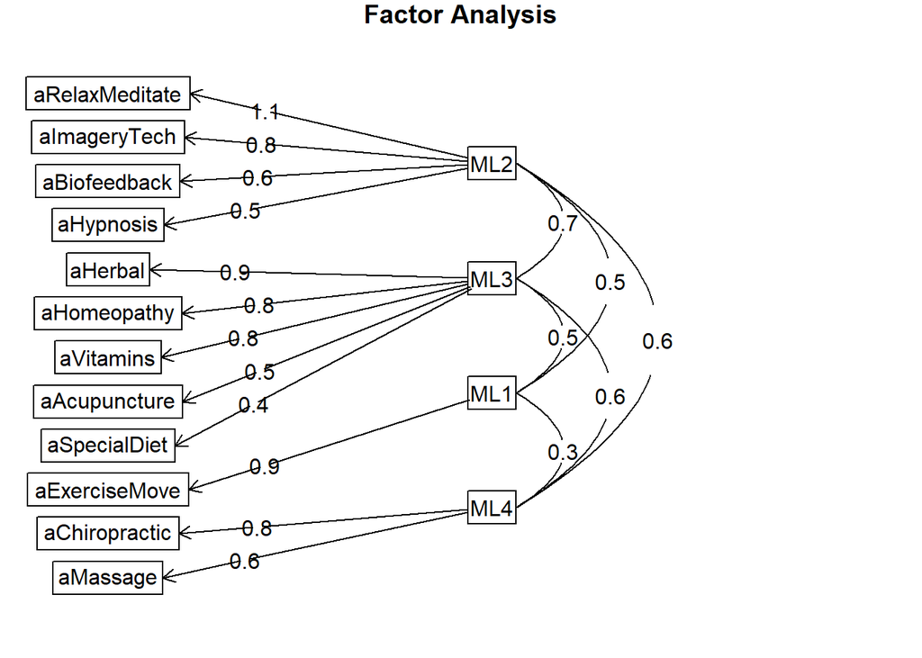

### Oblique rotation: oblimin

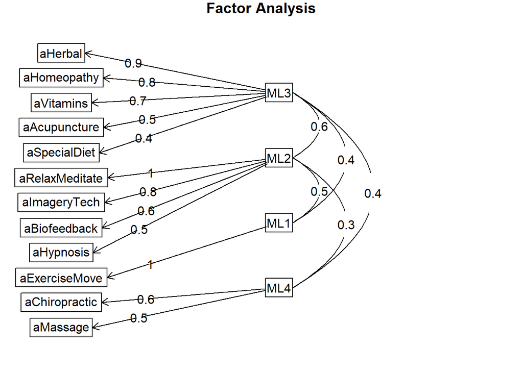

### Oblique rotation: cluster

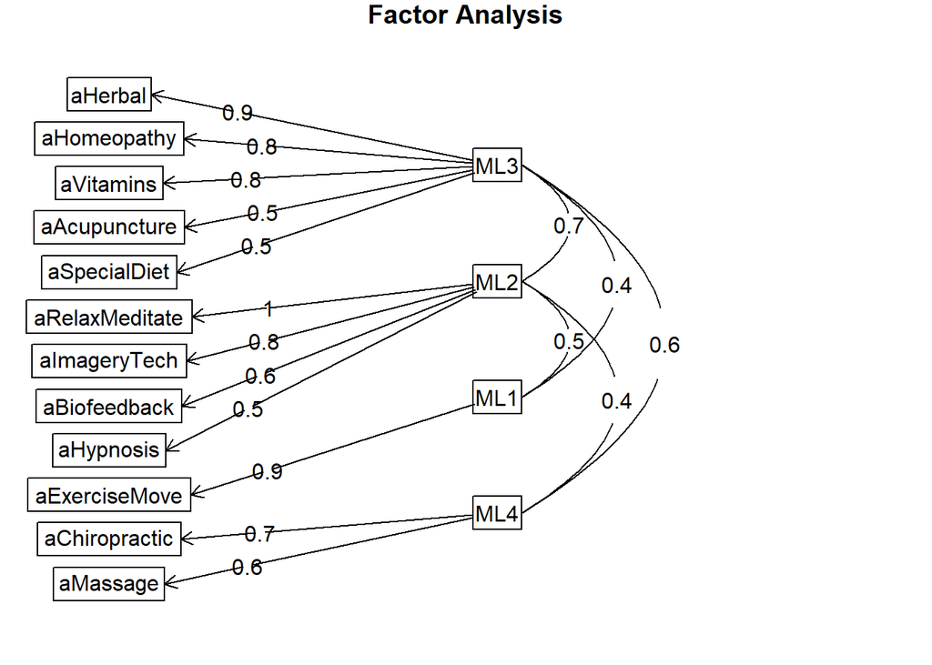

## Model fit comparison: Three and four factor models excluding prayer, spiritual healing, and energy healing

```
##                                       Model       TLI       CFI      BIC
## 1 Three Factor, Maximum Likelihood, Varimax 0.8281754 0.9141157 3395.890
## 2  Three Factor, Maximum Likelihood, Promax 0.8281754 0.9141157 3395.890
## 3 Three Factor, Maximum Likelihood, oblimin 0.8281754 0.9141157 3395.890
## 4 Three Factor, Maximum Likelihood, cluster 0.8281754 0.9141157 3395.890
## 5  Four Factor, Maximum Likelihood, Varimax 0.8722328 0.9535594 1788.721
## 6   Four Factor, Maximum Likelihood, Promax 0.8722328 0.9535594 1788.721
## 7  Four Factor, Maximum Likelihood, Oblimin 0.8722328 0.9535594 1788.721
## 8  Four Factor, Maximum Likelihood, Cluster 0.8722328 0.9535594 1788.721
##       RMSEA RMSEA_lower_bound RMSEA_upper_bound RMSEA_confidence       RMSR
## 1 0.1340460         0.1304178         0.1377325              0.9 0.05364173
## 2 0.1340460         0.1304178         0.1377325              0.9 0.05364173
## 3 0.1340460         0.1304178         0.1377325              0.9 0.05364173
## 4 0.1340460         0.1304178         0.1377325              0.9 0.05364173
## 5 0.1155838         0.1113305         0.1199140              0.9 0.03166634
```

[output cut: 21 more lines]